# STAT545 Assignment 3

Harper Cheng

9/26/2019

Load libraries and dataset

```r
library(dplyr)
library(ggplot2)
library(gapminder)
library(tidyr)
```

## Task Option 1

Report the absolute abundance of countries with low life expectancy over time by continent: Compute mean of worldwide life expectancy of each year. Then determine how many countries on each continent have a life expectancy less than this benchmark, for each year.

```r
t1 <- gapminder %>%
  group_by(year) %>%
  mutate(mu=mean(lifeExp)) %>%
  ungroup() %>%
  group_by(continent, year) %>%
  filter(lifeExp < mu)

# Produce a tibble display showing the number of countries on each continent having
# life expectancies less than the benchmark.
t1 %>%
  summarize(n=n()) %>%
  DT::datatable()
```

|  | continent | year | n |
| --- | --- | --- | --- |
| 1 | Africa | 1952 | 50 |
| 2 | Africa | 1957 | 50 |
| 3 | Africa | 1962 | 50 |
| 4 | Africa | 1967 | 50 |
| 5 | Africa | 1972 | 50 |
| 6 | Africa | 1977 | 49 |
| 7 | Africa | 1982 | 48 |
| 8 | Africa | 1987 | 46 |
| 9 | Africa | 1992 | 46 |
| 10 | Africa | 1997 | 45 |

[output cut: 34 more lines]

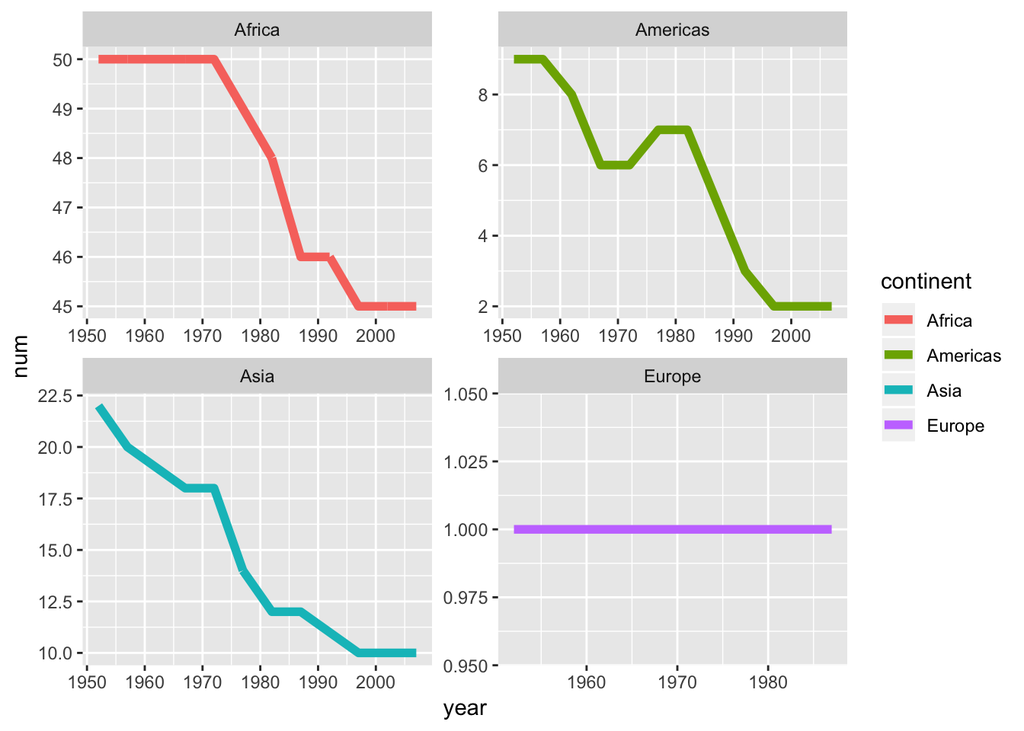

```r
# Produce a line graph showing the number of countries with life expectancies below
# the worldwide average. The graph is grouped by continent.
t1 %>%
  mutate(num=n()) %>%
  ggplot(aes(x=year, y=num, color=continent)) +
  geom_line(size=2) +
  facet_wrap(~continent, scales="free")
```

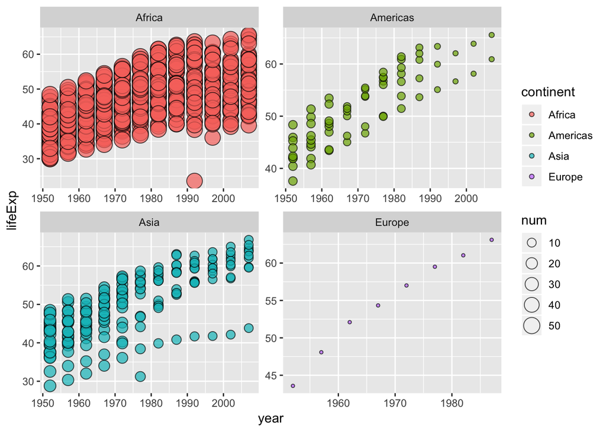

```r
# The bubble plot shows the relative abundance of countries with life expectancies
# below the worldwide average. The abundance is represented by the size of the bubble.
# The graph is grouped by continent.
t1 %>%
  mutate(num=n()) %>%
  ggplot(aes(x=year, y=lifeExp)) +
  geom_point(aes(size=num, fill=continent), alpha=0.7, shape=21) +
  facet_wrap(~continent, scale="free")
```

The number of countries with low life expectancy in Africa and Asia has been declining over the year, however, Africa still remains to be the continent with the most abundant countries below worldwide life expectancy. The statistic for Europe is very stable without any changes, while for America it fluctuated to some extent but has an overall decreasing trend. There were no countries in Oceania below worldwide life expectancy during the given years. Overall, less countries are below average life expectancy in recent years, indicating a change in the distribution of worldwide life expectancy. The bubble plot shows that Africa and Asia have greater number of such countries. And the general trend of life expectancy for each continent is increasing.